# Ford GoBike System Dataset Exploration

## Preliminary Wrangling

> This data set includes information about individual rides made in a bike-sharing system covering the greater San Francisco Bay area in February 2019.

```python
# import all packages and set plots to be embedded inline
import numpy as np
import pandas as pd
import matplotlib.pyplot as plt
import seaborn as sb
from matplotlib import rcParams

%matplotlib inline
```

> Load in your dataset and describe its properties through the questions below. Try and motivate your exploration goals through this section.

```python
# Loading the dataset
df1 = pd.read_csv('fordgobike-tripdata.csv')
df1.head()
```

|  | duration_sec | start_time | end_time | start_station_id | start_station_name | start_station_latitude | start_station_longitude | end_station_id | end_station_name | end_station_latitude | end_station_longitude | bike_id | user_type | member_birth_year | member_gender | bike_share_for_all_trip |
| --- | --- | --- | --- | --- | --- | --- | --- | --- | --- | --- | --- | --- | --- | --- | --- | --- |
| 0 | 52185 | 2019-02-28 17:32:10.1450 | 2019-03-01 08:01:55.9750 | 21.0 | Montgomery St BART Station (Market St at 2nd St) | 37.789625 | -122.400811 | 13.0 | Commercial St at Montgomery St | 37.794231 | -122.402923 | 4902 | Customer | 1984.0 | Male | No |
| 1 | 42521 | 2019-02-28 18:53:21.7890 | 2019-03-01 06:42:03.0560 | 23.0 | The Embarcadero at Steuart St | 37.791464 | -122.391034 | 81.0 | Berry St at 4th St | 37.775880 | -122.393170 | 2535 | Customer | NaN | NaN | No |
| 2 | 61854 | 2019-02-28 12:13:13.2180 | 2019-03-01 05:24:08.1460 | 86.0 | Market St at Dolores St | 37.769305 | -122.426826 | 3.0 | Powell St BART Station (Market St at 4th St) | 37.786375 | -122.404904 | 5905 | Customer | 1972.0 | Male | No |
| 3 | 36490 | 2019-02-28 17:54:26.0100 | 2019-03-01 04:02:36.8420 | 375.0 | Grove St at Masonic Ave | 37.774836 | -122.446546 | 70.0 | Central Ave at Fell St | 37.773311 | -122.444293 | 6638 | Subscriber | 1989.0 | Other | No |
| 4 | 1585 | 2019-02-28 23:54:18.5490 | 2019-03-01 00:20:44.0740 | 7.0 | Frank H Ogawa Plaza | 37.804562 | -122.271738 | 222.0 | 10th Ave at E 15th St | 37.792714 | -122.248780 | 4898 | Subscriber | 1974.0 | Male | Yes |

```python
# Dataset's shape and data-type
print(df1.shape)
print(df1.dtypes)
```

```
(183412, 16)
duration_sec                 int64
start_time                  object
end_time                    object
start_station_id           float64
start_station_name          object
start_station_latitude     float64
start_station_longitude    float64
end_station_id             float64
end_station_name            object
end_station_latitude       float64
end_station_longitude      float64
bike_id                      int64
user_type                   object
member_birth_year          float64
member_gender               object
bike_share_for_all_trip     object
dtype: object
```

```python
df1.info()
```

```
<class 'pandas.core.frame.DataFrame'>
RangeIndex: 183412 entries, 0 to 183411
Data columns (total 16 columns):
 #   Column                   Non-Null Count   Dtype
---  ------                   --------------   -----
 0   duration_sec             183412 non-null  int64
 1   start_time               183412 non-null  object
 2   end_time                 183412 non-null  object
 3   start_station_id         183215 non-null  float64
 4   start_station_name       183215 non-null  object
 5   start_station_latitude   183412 non-null  float64
 6   start_station_longitude  183412 non-null  float64
 7   end_station_id           183215 non-null  float64
 8   end_station_name         183215 non-null  object
 9   end_station_latitude     183412 non-null  float64
 10  end_station_longitude    183412 non-null  float64
 11  bike_id                  183412 non-null  int64
 12  user_type                183412 non-null  object
 13  member_birth_year        175147 non-null  float64
 14  member_gender            175147 non-null  object
 15  bike_share_for_all_trip  183412 non-null  object
dtypes: float64(7), int64(2), object(7)
memory usage: 22.4+ MB
```

```python
df1.describe()
```

|  | duration_sec | start_station_id | start_station_latitude | start_station_longitude | end_station_id | end_station_latitude | end_station_longitude | bike_id | member_birth_year |
| --- | --- | --- | --- | --- | --- | --- | --- | --- | --- |
| count | 183412.000000 | 183215.000000 | 183412.000000 | 183412.000000 | 183215.000000 | 183412.000000 | 183412.000000 | 183412.000000 | 175147.000000 |
| mean | 726.078435 | 138.590427 | 37.771223 | -122.352664 | 136.249123 | 37.771427 | -122.352250 | 4472.906375 | 1984.806437 |
| std | 1794.389780 | 111.778864 | 0.099581 | 0.117097 | 111.515131 | 0.099490 | 0.116673 | 1664.383394 | 10.116689 |
| min | 61.000000 | 3.000000 | 37.317298 | -122.453704 | 3.000000 | 37.317298 | -122.453704 | 11.000000 | 1878.000000 |
| 25% | 325.000000 | 47.000000 | 37.770083 | -122.412408 | 44.000000 | 37.770407 | -122.411726 | 3777.000000 | 1980.000000 |
| 50% | 514.000000 | 104.000000 | 37.780760 | -122.398285 | 100.000000 | 37.781010 | -122.398279 | 4958.000000 | 1987.000000 |
| 75% | 796.000000 | 239.000000 | 37.797280 | -122.286533 | 235.000000 | 37.797320 | -122.288045 | 5502.000000 | 1992.000000 |
| max | 85444.000000 | 398.000000 | 37.880222 | -121.874119 | 398.000000 | 37.880222 | -121.874119 | 6645.000000 | 2001.000000 |

```python
# Investigate the missing values!
df1.isnull().sum()
```

```
duration_sec                  0
start_time                    0
end_time                      0
start_station_id            197
start_station_name          197
start_station_latitude        0
start_station_longitude       0
end_station_id              197
end_station_name            197
end_station_latitude          0
end_station_longitude         0
bike_id                       0
user_type                     0
member_birth_year          8265
member_gender              8265
bike_share_for_all_trip       0
dtype: int64
```

```python
# Create new columns from start_time and end_time to help explore farther more

# Date columns
df1.start_time = pd.to_datetime(df1.start_time)
df1.end_time = pd.to_datetime(df1.end_time)

# Date columns
df1['start_date'] = df1.start_time.dt.strftime('%Y-%m-%d')
df1['end_date'] = df1.end_time.dt.strftime('%Y-%m-%d')

# Day columns
df1['start_day'] = df1.start_time.dt.strftime('%A')
df1['end_day'] = df1.end_time.dt.strftime('%A')

# Hour columns
df1['start_hour'] = df1.start_time.dt.strftime('%H')
df1['end_hour'] = df1.end_time.dt.strftime('%H')

df1.head()
```

|  | duration_sec | start_time | end_time | start_station_id | start_station_name | start_station_latitude | start_station_longitude | end_station_id | end_station_name | end_station_latitude | ... | user_type | member_birth_year | member_gender | bike_share_for_all_trip | start_date | end_date | start_day | end_day | start_hour | end_hour |
| --- | --- | --- | --- | --- | --- | --- | --- | --- | --- | --- | --- | --- | --- | --- | --- | --- | --- | --- | --- | --- | --- |
| 0 | 52185 | 2019-02-28 17:32:10.145 | 2019-03-01 08:01:55.975 | 21.0 | Montgomery St BART Station (Market St at 2nd St) | 37.789625 | -122.400811 | 13.0 | Commercial St at Montgomery St | 37.794231 | ... | Customer | 1984.0 | Male | No | 2019-02-28 | 2019-03-01 | Thursday | Friday | 17 | 08 |
| 1 | 42521 | 2019-02-28 18:53:21.789 | 2019-03-01 06:42:03.056 | 23.0 | The Embarcadero at Steuart St | 37.791464 | -122.391034 | 81.0 | Berry St at 4th St | 37.775880 | ... | Customer | NaN | NaN | No | 2019-02-28 | 2019-03-01 | Thursday | Friday | 18 | 06 |
| 2 | 61854 | 2019-02-28 12:13:13.218 | 2019-03-01 05:24:08.146 | 86.0 | Market St at Dolores St | 37.769305 | -122.426826 | 3.0 | Powell St BART Station (Market St at 4th St) | 37.786375 | ... | Customer | 1972.0 | Male | No | 2019-02-28 | 2019-03-01 | Thursday | Friday | 12 | 05 |
| 3 | 36490 | 2019-02-28 17:54:26.010 | 2019-03-01 04:02:36.842 | 375.0 | Grove St at Masonic Ave | 37.774836 | -122.446546 | 70.0 | Central Ave at Fell St | 37.773311 | ... | Subscriber | 1989.0 | Other | No | 2019-02-28 | 2019-03-01 | Thursday | Friday | 17 | 04 |
| 4 | 1585 | 2019-02-28 23:54:18.549 | 2019-03-01 00:20:44.074 | 7.0 | Frank H Ogawa Plaza | 37.804562 | -122.271738 | 222.0 | 10th Ave at E 15th St | 37.792714 | ... | Subscriber | 1974.0 | Male | Yes | 2019-02-28 | 2019-03-01 | Thursday | Friday | 23 | 00 |

5 rows × 22 columns

```python
# Convert new columns to datetime

# Date columns
df1.start_date = pd.to_datetime(df1.start_date)
df1.end_date = pd.to_datetime(df1.end_date)

# Day columns
df1['start_day'] = df1['start_day'].astype('category')
df1['end_day'] = df1['end_day'].astype('category')

# Hour columns
df1['start_hour'] = df1['start_hour'].astype('int64')
df1['end_hour'] = df1['end_hour'].astype('int64')

df1.info()
```

```
<class 'pandas.core.frame.DataFrame'>
RangeIndex: 183412 entries, 0 to 183411
Data columns (total 22 columns):
 #   Column                   Non-Null Count   Dtype
---  ------                   --------------   -----
 0   duration_sec             183412 non-null  int64
 1   start_time               183412 non-null  datetime64[ns]
 2   end_time                 183412 non-null  datetime64[ns]
 3   start_station_id         183215 non-null  float64
 4   start_station_name       183215 non-null  object
 5   start_station_latitude   183412 non-null  float64
 6   start_station_longitude  183412 non-null  float64
 7   end_station_id           183215 non-null  float64
 8   end_station_name         183215 non-null  object
 9   end_station_latitude     183412 non-null  float64
 10  end_station_longitude    183412 non-null  float64
 11  bike_id                  183412 non-null  int64
 12  user_type                183412 non-null  object
 13  member_birth_year        175147 non-null  float64
 14  member_gender            175147 non-null  object
 15  bike_share_for_all_trip  183412 non-null  object
 16  start_date               183412 non-null  datetime64[ns]
 17  end_date                 183412 non-null  datetime64[ns]
 18  start_day                183412 non-null  category
 19  end_day                  183412 non-null  category
 20  start_hour               183412 non-null  int64
 21  end_hour                 183412 non-null  int64
dtypes: category(2), datetime64[ns](4), float64(7), int64(4), object(5)
memory usage: 28.3+ MB
```

```python
# Check for duplicates
df1.duplicated().sum()
```

```
0
```

```python
# Check for users value_counts
print(df1.user_type.value_counts())
print(df1.member_gender.value_counts())
print(df1.bike_share_for_all_trip.value_counts())
```

```
Subscriber    163544
Customer       19868
Name: user_type, dtype: int64
Male      130651
Female     40844
Other       3652
Name: member_gender, dtype: int64
No     166053
Yes     17359
Name: bike_share_for_all_trip, dtype: int64
```

```python
# Convert user_type and member_gender data_type to category
df1['user_type'] = df1['user_type'].astype('category')
df1['member_gender'] = df1['member_gender'].astype('category')
```

```python
# Convert bike_share_for_all_trip data_type to boolean
df1.bike_share_for_all_trip = (df1.bike_share_for_all_trip == 'Yes')
```

```python
# Change duration_sec to duration_min
df1['duration_min'] = df1['duration_sec']/60
```

```python
# Remove all nulled rows
df1 = df1[df1['member_gender'].isnull() == False]
df1 = df1[df1['start_station_id'].isnull() == False]
df1.info()
```

```
<class 'pandas.core.frame.DataFrame'>
Int64Index: 174952 entries, 0 to 183411
Data columns (total 23 columns):
 #   Column                   Non-Null Count   Dtype
---  ------                   --------------   -----
 0   duration_sec             174952 non-null  int64
 1   start_time               174952 non-null  datetime64[ns]
 2   end_time                 174952 non-null  datetime64[ns]
 3   start_station_id         174952 non-null  float64
 4   start_station_name       174952 non-null  object
 5   start_station_latitude   174952 non-null  float64
 6   start_station_longitude  174952 non-null  float64
 7   end_station_id           174952 non-null  float64
 8   end_station_name         174952 non-null  object
 9   end_station_latitude     174952 non-null  float64
 10  end_station_longitude    174952 non-null  float64
 11  bike_id                  174952 non-null  int64
 12  user_type                174952 non-null  category
 13  member_birth_year        174952 non-null  float64
 14  member_gender            174952 non-null  category
 15  bike_share_for_all_trip  174952 non-null  bool
 16  start_date               174952 non-null  datetime64[ns]
 17  end_date                 174952 non-null  datetime64[ns]
 18  start_day                174952 non-null  category
 19  end_day                  174952 non-null  category
 20  start_hour               174952 non-null  int64
 21  end_hour                 174952 non-null  int64
 22  duration_min             174952 non-null  float64
dtypes: bool(1), category(4), datetime64[ns](4), float64(8), int64(4), object(2)
memory usage: 26.2+ MB
```

```python
df2 = df1.drop(columns= ['duration_sec', 'start_time', 'end_time'], inplace= False)
df2.head()
```

|  | start_station_id | start_station_name | start_station_latitude | start_station_longitude | end_station_id | end_station_name | end_station_latitude | end_station_longitude | bike_id | user_type | member_birth_year | member_gender | bike_share_for_all_trip | start_date | end_date | start_day | end_day | start_hour | end_hour | duration_min |
| --- | --- | --- | --- | --- | --- | --- | --- | --- | --- | --- | --- | --- | --- | --- | --- | --- | --- | --- | --- | --- |
| 0 | 21.0 | Montgomery St BART Station (Market St at 2nd St) | 37.789625 | -122.400811 | 13.0 | Commercial St at Montgomery St | 37.794231 | -122.402923 | 4902 | Customer | 1984.0 | Male | False | 2019-02-28 | 2019-03-01 | Thursday | Friday | 17 | 8 | 869.750000 |
| 2 | 86.0 | Market St at Dolores St | 37.769305 | -122.426826 | 3.0 | Powell St BART Station (Market St at 4th St) | 37.786375 | -122.404904 | 5905 | Customer | 1972.0 | Male | False | 2019-02-28 | 2019-03-01 | Thursday | Friday | 12 | 5 | 1030.900000 |
| 3 | 375.0 | Grove St at Masonic Ave | 37.774836 | -122.446546 | 70.0 | Central Ave at Fell St | 37.773311 | -122.444293 | 6638 | Subscriber | 1989.0 | Other | False | 2019-02-28 | 2019-03-01 | Thursday | Friday | 17 | 4 | 608.166667 |
| 4 | 7.0 | Frank H Ogawa Plaza | 37.804562 | -122.271738 | 222.0 | 10th Ave at E 15th St | 37.792714 | -122.248780 | 4898 | Subscriber | 1974.0 | Male | True | 2019-02-28 | 2019-03-01 | Thursday | Friday | 23 | 0 | 26.416667 |
| 5 | 93.0 | 4th St at Mission Bay Blvd S | 37.770407 | -122.391198 | 323.0 | Broadway at Kearny | 37.798014 | -122.405950 | 5200 | Subscriber | 1959.0 | Male | False | 2019-02-28 | 2019-03-01 | Thursday | Friday | 23 | 0 | 29.883333 |

```python
# Convert member_birth_year data_type to int64
df2['member_birth_year'] = df2['member_birth_year'].astype('int64')
```

```python
# Convert weekdays into Ordered Categorical in start_day column

df2['start_day'] = pd.Categorical(df2['start_day'], dtype="category", categories=
    ['Saturday','Sunday','Monday','Tuesday','Wednesday','Thursday','Friday'],
    ordered=False)
ordered_start_days = df2['start_day'].value_counts().sort_index()
ordered_start_days
```

```
Saturday     14414
Sunday       14512
Monday       25641
Tuesday      30584
Wednesday    28426
Thursday     33712
Friday       27663
Name: start_day, dtype: int64
```

```python
# Convert weekdays into Ordered Categorical in end_day column
df2['end_day'] = pd.Categorical(df2['end_day'], dtype="category", categories=
    ['Saturday','Sunday','Monday','Tuesday','Wednesday','Thursday','Friday',],
    ordered=False)
ordered_end_days = df2['end_day'].value_counts().sort_index()
ordered_end_days
```

```
Saturday     14422
Sunday       14519
Monday       25641
Tuesday      30591
Wednesday    28417
Thursday     33707
Friday       27655
Name: end_day, dtype: int64
```

```python
cols = df2.columns.tolist()
cols
```

```
['start_station_id',
 'start_station_name',
 'start_station_latitude',
 'start_station_longitude',
 'end_station_id',
 'end_station_name',
 'end_station_latitude',
 'end_station_longitude',
 'bike_id',
 'user_type',
 'member_birth_year',
 'member_gender',
 'bike_share_for_all_trip',
 'start_date',
 'end_date',
 'start_day',
 'end_day',
 'start_hour',
 'end_hour',
 'duration_min']
```

```python
# Reorder columns
df = df2[[ 'duration_min',
           'start_date',
           'end_date',
           'start_station_id',
           'start_station_name',
           'start_station_latitude',
           'start_station_longitude',
           'end_station_id',
           'end_station_name',
           'end_station_latitude',
           'end_station_longitude',
           'bike_id',
           'user_type',
           'member_birth_year',
           'member_gender',
           'bike_share_for_all_trip',
           'start_day',
           'end_day',
           'start_hour',
           'end_hour']]

df.head()
```

|  | duration_min | start_date | end_date | start_station_id | start_station_name | start_station_latitude | start_station_longitude | end_station_id | end_station_name | end_station_latitude | end_station_longitude | bike_id | user_type | member_birth_year | member_gender | bike_share_for_all_trip | start_day | end_day | start_hour | end_hour |
| --- | --- | --- | --- | --- | --- | --- | --- | --- | --- | --- | --- | --- | --- | --- | --- | --- | --- | --- | --- | --- |
| 0 | 869.750000 | 2019-02-28 | 2019-03-01 | 21.0 | Montgomery St BART Station (Market St at 2nd St) | 37.789625 | -122.400811 | 13.0 | Commercial St at Montgomery St | 37.794231 | -122.402923 | 4902 | Customer | 1984 | Male | False | Thursday | Friday | 17 | 8 |
| 2 | 1030.900000 | 2019-02-28 | 2019-03-01 | 86.0 | Market St at Dolores St | 37.769305 | -122.426826 | 3.0 | Powell St BART Station (Market St at 4th St) | 37.786375 | -122.404904 | 5905 | Customer | 1972 | Male | False | Thursday | Friday | 12 | 5 |
| 3 | 608.166667 | 2019-02-28 | 2019-03-01 | 375.0 | Grove St at Masonic Ave | 37.774836 | -122.446546 | 70.0 | Central Ave at Fell St | 37.773311 | -122.444293 | 6638 | Subscriber | 1989 | Other | False | Thursday | Friday | 17 | 4 |
| 4 | 26.416667 | 2019-02-28 | 2019-03-01 | 7.0 | Frank H Ogawa Plaza | 37.804562 | -122.271738 | 222.0 | 10th Ave at E 15th St | 37.792714 | -122.248780 | 4898 | Subscriber | 1974 | Male | True | Thursday | Friday | 23 | 0 |
| 5 | 29.883333 | 2019-02-28 | 2019-03-01 | 93.0 | 4th St at Mission Bay Blvd S | 37.770407 | -122.391198 | 323.0 | Broadway at Kearny | 37.798014 | -122.405950 | 5200 | Subscriber | 1959 | Male | False | Thursday | Friday | 23 | 0 |

```python
# Last Check!
df.info()
```

```
<class 'pandas.core.frame.DataFrame'>
Int64Index: 174952 entries, 0 to 183411
Data columns (total 20 columns):
 #   Column                   Non-Null Count   Dtype
---  ------                   --------------   -----
 0   duration_min             174952 non-null  float64
 1   start_date               174952 non-null  datetime64[ns]
 2   end_date                 174952 non-null  datetime64[ns]
 3   start_station_id         174952 non-null  float64
 4   start_station_name       174952 non-null  object
 5   start_station_latitude   174952 non-null  float64
 6   start_station_longitude  174952 non-null  float64
 7   end_station_id           174952 non-null  float64
 8   end_station_name         174952 non-null  object
 9   end_station_latitude     174952 non-null  float64
 10  end_station_longitude    174952 non-null  float64
 11  bike_id                  174952 non-null  int64
 12  user_type                174952 non-null  category
 13  member_birth_year        174952 non-null  int64
 14  member_gender            174952 non-null  category
 15  bike_share_for_all_trip  174952 non-null  bool
 16  start_day                174952 non-null  category
 17  end_day                  174952 non-null  category
 18  start_hour               174952 non-null  int64
 19  end_hour                 174952 non-null  int64
dtypes: bool(1), category(4), datetime64[ns](2), float64(7), int64(4), object(2)
memory usage: 22.2+ MB
```

```python
df.describe()
```

|  | duration_min | start_station_id | start_station_latitude | start_station_longitude | end_station_id | end_station_latitude | end_station_longitude | bike_id | member_birth_year | start_hour | end_hour |
| --- | --- | --- | --- | --- | --- | --- | --- | --- | --- | --- | --- |
| count | 174952.000000 | 174952.000000 | 174952.000000 | 174952.000000 | 174952.000000 | 174952.000000 | 174952.000000 | 174952.000000 | 174952.000000 | 174952.000000 | 174952.000000 |
| mean | 11.733379 | 139.002126 | 37.771220 | -122.351760 | 136.604486 | 37.771414 | -122.351335 | 4482.587555 | 1984.803135 | 13.456165 | 13.609533 |
| std | 27.370082 | 111.648819 | 0.100391 | 0.117732 | 111.335635 | 0.100295 | 0.117294 | 1659.195937 | 10.118731 | 4.734282 | 4.748029 |
| min | 1.016667 | 3.000000 | 37.317298 | -122.453704 | 3.000000 | 37.317298 | -122.453704 | 11.000000 | 1878.000000 | 0.000000 | 0.000000 |
| 25% | 5.383333 | 47.000000 | 37.770407 | -122.411901 | 44.000000 | 37.770407 | -122.411647 | 3799.000000 | 1980.000000 | 9.000000 | 9.000000 |
| 50% | 8.500000 | 104.000000 | 37.780760 | -122.398279 | 101.000000 | 37.781010 | -122.397437 | 4960.000000 | 1987.000000 | 14.000000 | 14.000000 |
| 75% | 13.150000 | 239.000000 | 37.797320 | -122.283093 | 238.000000 | 37.797673 | -122.286533 | 5505.000000 | 1992.000000 | 17.000000 | 18.000000 |
| max | 1409.133333 | 398.000000 | 37.880222 | -121.874119 | 398.000000 | 37.880222 | -121.874119 | 6645.000000 | 2001.000000 | 23.000000 | 23.000000 |

### What is the structure of your dataset?

> There are 174,952 bike-share prosses occurred in February 2019 in San Francisco Bay Area only. The dataset came originally with 16 features like (trip durations, start snd end dates and stations, station names, ids, longitude and latitude, users' type, gender, and age, and whether they bike-share for all trips or not. Most variables are numeric in nature, but there're other categorical variables as well. Of course, after data cleaning the dataset there are some changes in order, shape, and data-type. There is 4607 bike in the dataset, the 163544 Subscriber, Customer 19868, 130651 Male, 40844 Female.

### What is/are the main feature(s) of interest in your dataset?

> I'm interested to investigate the trip duration and seeing the proportion of bikers' type, gender, and ages. Also, the start and end day/time investigation.

### What features in the dataset do you think will help support your investigation into your feature(s) of interest?

> Fun fact, the maximum ride duration is 1409 minutes that's 23.48 hours, obviously, it means that the company must have a policy that obliges its members from keeping the bike for more than 24h!

## Univariate Exploration

> In this section, investigate distributions of individual variables. If you see unusual points or outliers, take a deeper look to clean things up and prepare yourself to look at relationships between variables.

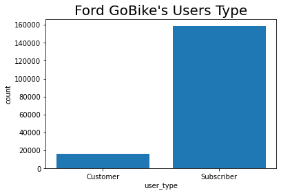

```python
# Display the size of the user type in bar chart
# Return the Series having unique values of user_type to see the most and least used bike
x = df['user_type'].unique()

# Return the Series having frequency count of each unique value
y = df['user_type'].value_counts(sort=False)

plt.figure(figsize=[6, 4])
plt.bar(x, y)

# Labeling the axes
plt.xlabel('user_type')
plt.ylabel('count')
plt.title(label = "Ford GoBike's Users Type",
          fontsize=20, loc='center')

# Dsiplay the plot
plt.show()
```

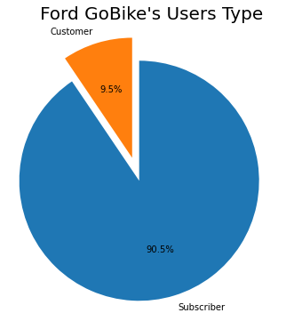

```python
# Display the proportion of user types in pie chart
user_type = df['user_type'].value_counts()

plt.figure(figsize=[8, 6])
plt.pie(user_type, labels = user_type.index,
        autopct='%1.1f%%', explode=(0, 0.2), startangle=90,
        counterclock = False,);
plt.title(label = "Ford GoBike's Users Type",
          fontsize=20, loc='center')
plt.axis('square');
```

**I used bar and pie chart to display Ford GoBike's users type. 90.5% Subscribers and only 9.5% are Customers.**

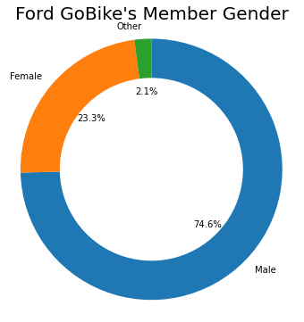

```python
# Display the proportion of member gender in a Doughnuts chart

member_gender = df['member_gender'].value_counts()

plt.figure(figsize=[8, 6])
plt.pie(member_gender, labels = member_gender.index,
        autopct='%1.1f%%', startangle=90,
        counterclock = False, wedgeprops = {'width' : 0.3});
plt.title(label = "Ford GoBike's Member Gender",
          fontsize=20, loc='center')

plt.axis('square');
```

**Here, I used the doughnuts chart to display Ford GoBike's member gender. It seems that in Feb 19 there are 74.6% are males, 23.3% are females, and 2.1 are other gender**

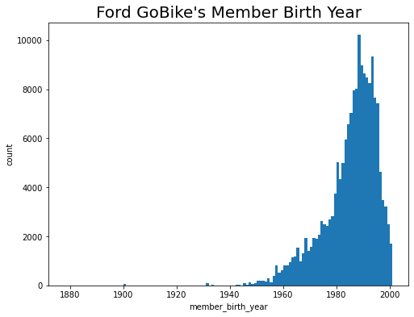

```python
# Display the member birth year distribution as a Histogram
plt.figure(figsize=[8, 6])

bins = np.arange(df['member_birth_year'].min(), df['member_birth_year'].max()+1, 1)
# Labeling the axes
plt.xlabel('member_birth_year')
plt.ylabel('count')
plt.hist(data=df, x='member_birth_year', bins=bins);
plt.title(label = "Ford GoBike's Member Birth Year", fontsize=20, loc='center')
```

**I wanted to represent the memembers' birth year in a Histogram and it's not clear there are outliers and I need to remove them.**

```python
# Identify ages from member_birth_year
df['age'] = 2019 - df['member_birth_year']
df['age'] = df['age'].astype(int)
df['age'].describe() # Anticipating outliers
```

```
count    174952.000000
mean         34.196865
std          10.118731
min          18.000000
25%          27.000000
50%          32.000000
75%          39.000000
max         141.000000
Name: age, dtype: float64
```

```python
#Remove Outliers over 60 years
df = df[df['age'] <= 60]
df['age'].describe()
```

```
count    171422.000000
mean         33.523387
std           8.954923
min          18.000000
25%          27.000000
50%          32.000000
75%          38.000000
max          60.000000
Name: age, dtype: float64
```

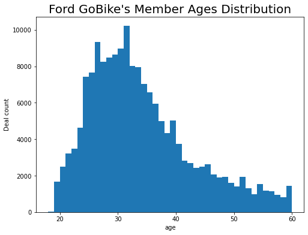

```python
# Display the actual age distribution as a Histogram
plt.figure(figsize=[8, 6])
bins = np.arange(df['age'].min(), df['age'].max()+1, 1)
plt.hist(data=df, x='age', bins=bins);
# Labeling the axes
plt.xlabel('age')
plt.ylabel('Deal count')
plt.title(label = "Ford GoBike's Member Ages Distribution", fontsize=20, loc='center')
```

**Now, It's clear that in average the age of Ford GoBike's members are 33.5, the distribution is skewed to the right.**

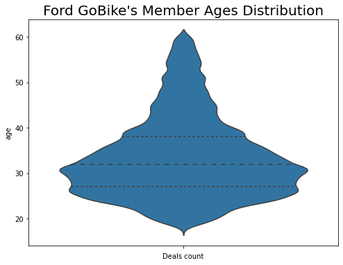

```python
# Display the members' age distribution as a Violinplot

plt.figure(figsize=[8, 6])
sb.violinplot(data=df, y='age', inner='quartile');
# Labeling the axes
plt.xlabel('Deals count')
plt.ylabel('age')
plt.title(label = "Ford GoBike's Member Ages Distribution", fontsize=20, loc='center')
```

**Another look at the Ford GoBike's members age distribution using Violinplot. Next, I want to display wWhich bike are most frequently used on Feb 19**

```python
# Which bike are most used?
df['bike_id'].mode()
```

```
0    4794
dtype: int64
```

```python
df['bike_id'] = df['bike_id'].apply(lambda x: int(x))
bike_id_order = df.bike_id.value_counts().index
bike_id_order
```

```
Int64Index([4794, 4814, 5175, 4450, 5145, 4834, 4773, 4812, 4422, 5482,
            ...
            2297,   96, 3114, 6271, 1194, 5067, 2401,  231, 3222,   70],
           dtype='int64', length=4606)
```

```python
# The bike id that is most used (Feb 19)
df.dropna(subset=['bike_id'])
df['bike_id'].value_counts().idxmax()
```

```
4794
```

```python
# How much time bike (4794) used (Feb 19)
df['bike_id'].value_counts().max()
```

```
176
```

```python
# The bike id that is least used (Feb 19)
df.dropna(subset=['bike_id'])
df['bike_id'].value_counts().idxmin()
```

```
712
```

```python
# How much time bike (712) used (Feb 19)
df['bike_id'].value_counts().min()
```

```
1
```

```python
# Top 10 bike used (Feb 19)
df['bike_id'].value_counts().nlargest(10)
```

```
4794    176
4814    165
5175    165
4450    165
5145    164
4834    162
4773    160
4812    160
4422    160
5482    159
Name: bike_id, dtype: int64
```

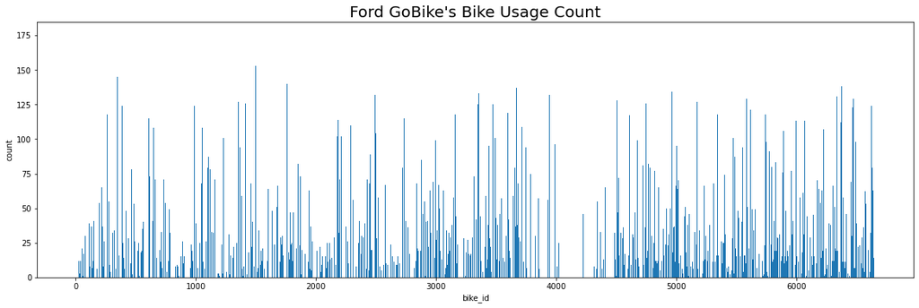

```python
# Display bike that frequently used bike in bar chart
x = df['bike_id'].unique()

# Return the Series having frequency count of each unique value
y = df['bike_id'].value_counts(sort=False)

rcParams['figure.figsize'] = 20, 6
plt.bar(x, y)

# Labeling the axes
plt.xlabel('bike_id')
plt.ylabel('count')
plt.title(label = "Ford GoBike's Bike Usage Count",
          fontsize=20, loc='center')

# Dsiplay the plot
plt.show()
```

**Well, I need to right some code to display the top 20 bike frequently used as this plot doesn't help.**

```python
# Investigate the top 20 IDs
top_20 = df['bike_id'].value_counts().nlargest(20)
top_20.index
```

```
Int64Index([4794, 4814, 5175, 4450, 5145, 4834, 4773, 4812, 4422, 5482, 5048,
            4956, 5274, 4653, 5351, 5014, 5325, 4923, 5218, 4767],
           dtype='int64')
```

```python
top_20
```

```
4794    176
4814    165
5175    165
4450    165
5145    164
4834    162
4773    160
4812    160
4422    160
5482    159
5048    158
4956    158
5274    158
4653    155
5351    155
5014    155
5325    154
4923    153
5218    153
4767    153
Name: bike_id, dtype: int64
```

```python
top_20_order = top_20.index
top_20_order
```

```
Int64Index([4794, 4814, 5175, 4450, 5145, 4834, 4773, 4812, 4422, 5482, 5048,
            4956, 5274, 4653, 5351, 5014, 5325, 4923, 5218, 4767],
           dtype='int64')
```

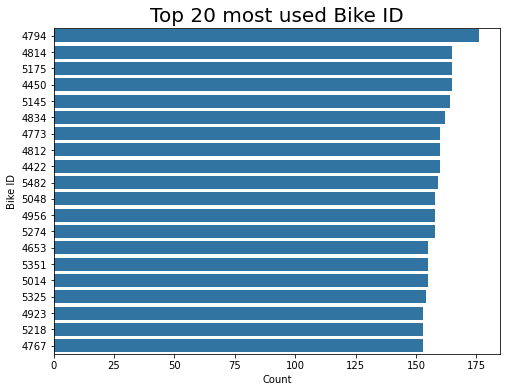

```python
# Let's display top 20 used bike Feb (19)
plt.figure(figsize=[8, 6])
base_color = sb.color_palette()[0]

sb.countplot(data=df, y= 'bike_id', color=base_color , order=top_20_order);

# Labeling the axes
plt.ylabel('Bike ID')
plt.xlabel('Count')
plt.title(label = "Top 20 most used Bike ID", fontsize=20, loc='center')
```

**Here are the top 20 bike frequently used on Feb 19, but I need to simplify the code and present it in a better way.**

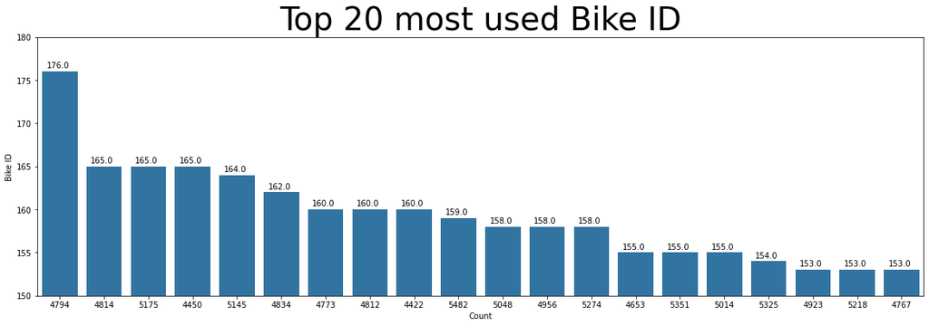

```python
# Let's display top 20 used bike Feb (19) with limits
rcParams['figure.figsize'] = 20, 6

THRESHOLD = 150
use_freq = df['bike_id'].value_counts()
idx = np.sum(use_freq > THRESHOLD)
most_uses = use_freq.index[:idx]
df_sub = df.loc[df['bike_id'].isin(most_uses)]

# Get the indexes of the Series
use_order = top_20.index

base_color = sb.color_palette()[0];

ax = sb.countplot(data=df_sub, x='bike_id', order=use_order, color = base_color);
plt.ylim([150, 180]);

for p in ax.patches:
   ax.annotate('{:.1f}'.format(p.get_height()), (p.get_x()+0.10, p.get_height()+0.40))

# Labeling the axes
plt.ylabel('Bike ID')
plt.xlabel('Count')
plt.title(label = "Top 20 most used Bike ID", fontsize=40, loc='center');
```

**Finally, the top 20 bikes frequently used on Feb 19, the most used bike is id: 4794 with 176 trips. Next, I'll investigate the average daytime and trip duration**

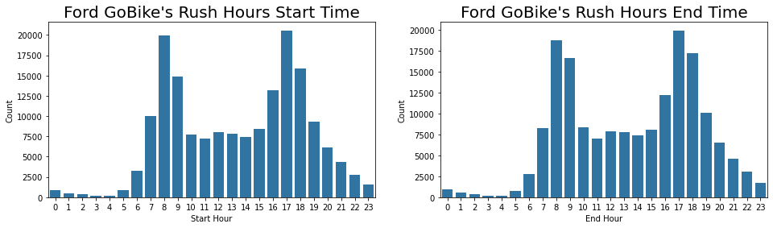

```python
# Let's investigate the daytime and trip duration
# Display deals counts each day in a Countplot

rcParams['figure.figsize'] = 16, 4

plt.subplot(1, 2, 1)
sb.countplot(data=df, x='start_hour', color=base_color);
# Labeling the axes
plt.xlabel('Start Hour')
plt.ylabel('Count')
plt.title(label = "Ford GoBike's Rush Hours Start Time", fontsize=20, loc='center')

plt.subplot(1, 2, 2)
sb.countplot(data=df, x='end_hour', color=base_color);
# Labeling the axes
plt.xlabel('End Hour')
plt.ylabel('Count')
plt.title(label = "Ford GoBike's Rush Hours End Time", fontsize=20, loc='center')
```

**I look like there are a similarity between the start time and end time duration. the rush time of the day are 8am and 5pm.**

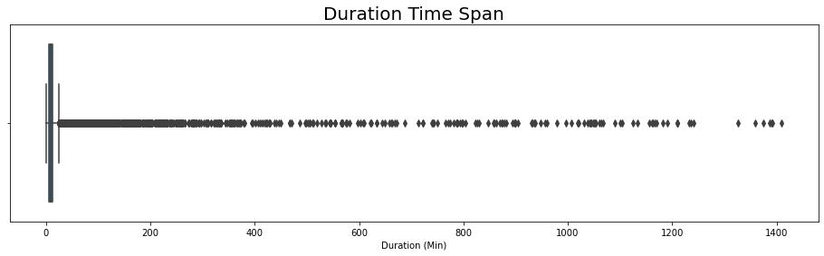

```python
# Let's just investigate the duration for outliers
sb.boxplot(data=df, x='duration_min');

# Labeling the axes
plt.xlabel('Duration (Min)')
plt.title(label = "Duration Time Span", fontsize=20, loc='center')
```

```python
df['duration_min'].describe()
```

```
count    171422.000000
mean         11.720437
std          27.577417
min           1.016667
25%           5.383333
50%           8.500000
75%          13.116667
max        1409.133333
Name: duration_min, dtype: float64
```

```python
# Let's keep only 2 hours trip duration to interpret easily
sdur = df[df['duration_min'] <= 120]
sdur['duration_min'].describe()
```

```
count    170893.000000
mean         10.631209
std           8.950977
min           1.016667
25%           5.366667
50%           8.466667
75%          13.050000
max         119.566667
Name: duration_min, dtype: float64
```

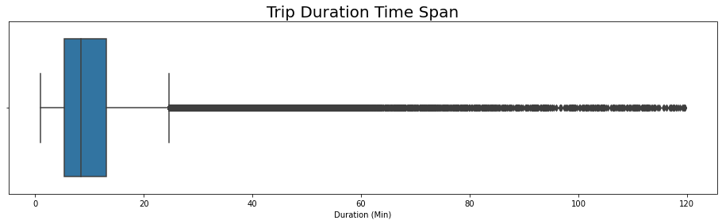

```python
# I'll repeat the same boxplot hear
sb.boxplot(data=sdur, x='duration_min');

# Labeling the axes
plt.xlabel('Duration (Min)')
plt.title(label = "Trip Duration Time Span", fontsize=20, loc='center')
```

```python
# Let's keep only 1 hours trip duration to interpret easily
zdur = df[df['duration_min'] <= 60]
zdur['duration_min'].describe()
```

```
count    170062.000000
mean         10.282960
std           7.363183
min           1.016667
25%           5.350000
50%           8.433333
75%          12.966667
max          59.933333
Name: duration_min, dtype: float64
```

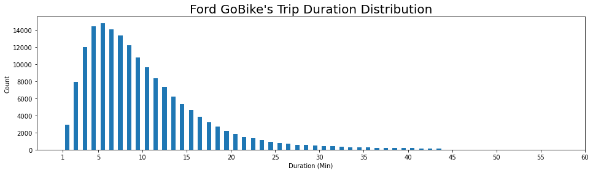

```python
# Display the distribution of trip duration by one hour
bins = np.arange(0, 45, 1)

plt.hist(data=zdur, x='duration_min', bins=bins, rwidth= 0.5);

plt.xticks([1, 5, 10, 15, 20, 25, 30, 35, 40, 45, 50, 55, 60])
# Labeling the axes
plt.xlabel('Duration (Min)')
plt.ylabel('Count')
plt.title(label = "Ford GoBike's Trip Duration Distribution", fontsize=20, loc='center')
```

**I want to show the actual trip duration's distribution in on hour by minutes. Looks like 5 min in the winner.**

```python
#Let's check it out
zdur['duration_min'].mode()

#Look like I was half wrong! it's 4.5 min.
```

```
0    4.533333
dtype: float64
```

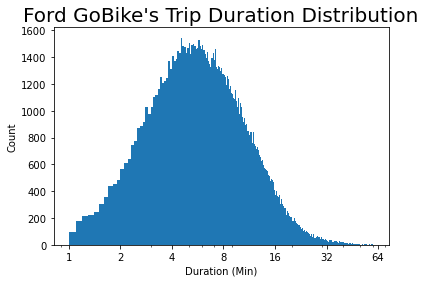

```python
# Desplay the distribution of trip duration as a histogram
plt.figure(figsize=[6, 4])

bins = np.arange(1, zdur['duration_min'].max()+0.1, 0.1)

plt.xscale('log')

plt.xticks([1, 2, 4, 8, 16, 32, 64], [1, 2, 4, 8, 16, 32, 64]);

plt.hist(data=zdur, x='duration_min', bins=bins);

# Labeling the axes
plt.xlabel('Duration (Min)')
plt.ylabel('Count')
plt.title(label = "Ford GoBike's Trip Duration Distribution", fontsize=20, loc='center')
```

**Lastly, We can see here that in a log scale, in a span of 1 hour trip duration the curve appears pretty normal distribution. Next, let's figure out which is the most frequent station start and end with.**

```python
# Most start and end Station ID
print(df['start_station_id'].mode())
print(df['end_station_id'].mode())
```

```
0    58.0
dtype: float64
0    67.0
dtype: float64
```

```python
# The start station id with the most occurrence (Feb 19)
df.dropna(subset=['start_station_id'])
print(df['start_station_id'].value_counts().idxmax())

# How much time start (Feb 19)
df['start_station_id'].value_counts().max()
```

```
58.0
```

```
3626
```

```python
# The start station id with the least occurrence (Feb 19)
df.dropna(subset=['start_station_id'])
print(df['start_station_id'].value_counts().idxmin())

# How much time start (Feb 19)
df['start_station_id'].value_counts().min()
```

```
344.0
```

```
2
```

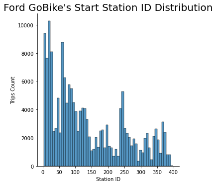

```python
# Display count distribution of the start station id (Feb 19)
plt.figure(figsize = [12, 5])
sb.displot(df['start_station_id'], kind='hist');

# Labeling the axes
plt.xlabel('Station ID')
plt.ylabel('Trips Count')
plt.title(label = "Ford GoBike's Start Station ID Distribution", fontsize=20, loc='center')
```

**Looks like the top frequent station to start a trip is the one with id no. 58 with 3626 trip starting on Feb 19.**

```python
# The end station id with the most occurrence (Feb 19)
df.dropna(subset=['end_station_id'])
print(df['end_station_id'].value_counts().idxmax())

# How much time end (Feb 19)
df['end_station_id'].value_counts().max()
```

```
67.0
```

```
4552
```

```python
# The end station id with the least occurrence (Feb 19)
df.dropna(subset=['end_station_id'])
print(df['end_station_id'].value_counts().idxmin())

# How much time end (Feb 19)
df['end_station_id'].value_counts().min()
```

```
224.0
```

```
4
```

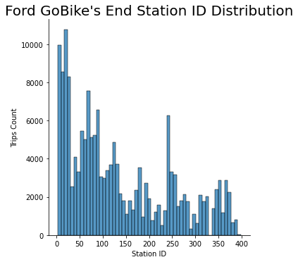

```python
# Display count distribution of the end station id (Feb 19)
sb.displot(df['end_station_id'], kind='hist');

# Labeling the axes
plt.xlabel('Station ID')
plt.ylabel('Trips Count')
plt.title(label = "Ford GoBike's End Station ID Distribution", fontsize=20, loc='center')
```

**However, the top frequent station to end a trip is the one with id no. 67 with 4552 trip ending on Feb 19.**

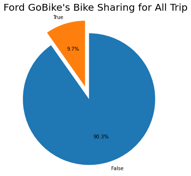

```python
# Display the proportion of boolian of bike_share_for_all_trip in pie chart
bike_share = df['bike_share_for_all_trip'].value_counts()

plt.figure(figsize=[8, 6])
plt.pie(bike_share, labels = bike_share.index,
        autopct='%1.1f%%', explode=(0, 0.2), startangle=90,
        counterclock = False);
plt.title(label = "Ford GoBike's Bike Sharing for All Trip",
          fontsize=20, loc='center')
plt.axis('square');
```

**The last univariate exploration is a pie chart represents Ford GoBike's members does share bikes for all trip or not. 90.3% o not share, and only 9.7% do share.**

### Discuss the distribution(s) of your variable(s) of interest. Were there any unusual points? Did you need to perform any transformations?

> Regarding the univariate exploration, I don't think I need to perform any further transformations other than what is already done.

### Of the features you investigated, were there any unusual distributions? Did you perform any operations on the data to tidy, adjust, or change the form of the data? If so, why did you do this?

> I made some cleaning and adjustments to the dataset in order to be able to represent the best out of the analysis.
> - I created new column represents the members age out of member_birth_year's column and remove the outliers over 60 years.
> - I also did some changes to the duration_min by removing the outliers over 2 hours in new data frame, then go farther removing over 1 hours in another new data frame to represent the accurate information about trip duration time span.
> - And of course I did perform some data wrangling and cleaning on the data in the beginning to tidy, adjust, and change the form of the dataset. The reason I did this is because the dataset needed some changes so I'll be able to perform data visualization operations in the best way possible.

## Bivariate Exploration

> In this section, investigate relationships between pairs of variables in your data. Make sure the variables that you cover here have been introduced in some fashion in the previous section (univariate exploration).

```python
# create dummy dataframe for top 20 to display bike id frequent usage during Feb 19 in a bivariat pointplot
top_20_df = pd.DataFrame({'bike_id': [4794, 4814, 5175, 4450, 5145, 4834, 4773, 4812, 4422, 5482, 5048,
                            4956, 5274, 4653, 5351, 5014, 5325, 4923, 5218, 4767],
                          'count': [176, 165, 165, 165, 164, 162, 160, 160, 160, 159, 158,
                            158, 158, 155, 155, 155, 154, 153, 153, 153]}
               )
top_20_df.head(20)
```

|  | bike_id | count |
| --- | --- | --- |
| 0 | 4794 | 176 |
| 1 | 4814 | 165 |
| 2 | 5175 | 165 |
| 3 | 4450 | 165 |
| 4 | 5145 | 164 |
| 5 | 4834 | 162 |
| 6 | 4773 | 160 |
| 7 | 4812 | 160 |
| 8 | 4422 | 160 |
| 9 | 5482 | 159 |
| 10 | 5048 | 158 |
| 11 | 4956 | 158 |
| 12 | 5274 | 158 |
| 13 | 4653 | 155 |
| 14 | 5351 | 155 |
| 15 | 5014 | 155 |
| 16 | 5325 | 154 |
| 17 | 4923 | 153 |
| 18 | 5218 | 153 |
| 19 | 4767 | 153 |

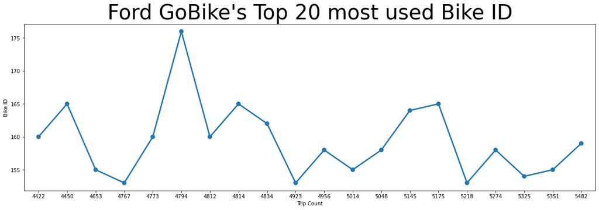

```python
# Top 20 bikes used in (Feb 19) displayed in point plot
from matplotlib import rcParams
rcParams['figure.figsize'] = 20, 6
sb.pointplot(data=top_20_df, x='bike_id', y='count', ci='sd')
plt.xticks(rotation=0);

# Labeling the axes
plt.ylabel('Bike ID')
plt.xlabel('Trip Count')
plt.title(label = "Ford GoBike's Top 20 most used Bike ID", fontsize=40, loc='center');
```

**I wanted to re-display the top 20 bikes of February 2019, but in a bivariate point plot. We can see clearly that the most bike used frequently is the bike with id: 4794**

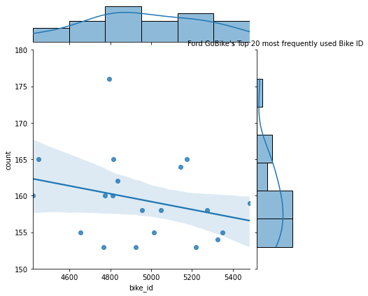

```python
# Top 20 bikes used in (Feb 19) displayed in bar plot
sb.jointplot(data=top_20_df, x='bike_id', y= 'count', kind="reg");
plt.ylim([150, 180])

# Labeling the axes
plt.ylabel('Bike ID')
plt.xlabel('Trip Count')
plt.title(label = "Ford GoBike's Top 20 most frequently used Bike ID", fontsize=10, loc='center');
```

**With this regression model, we can see here that between 152-161 trips are the most frequent time of using the same bike during Feb (19). Next, lets see the correlation between variables.**

```python
cols = df.columns.tolist()
print(cols)
df.info()
```

```
['duration_min', 'start_date', 'end_date', 'start_station_id', 'start_station_name', 'start_station_latitude', 'start_station_longitude', 'end_station_id', 'end_station_name', 'end_station_latitude', 'end_station_longitude', 'bike_id', 'user_type', 'member_birth_year', 'member_gender', 'bike_share_f…
<class 'pandas.core.frame.DataFrame'>
Int64Index: 171422 entries, 0 to 183411
Data columns (total 21 columns):
 #   Column                   Non-Null Count   Dtype
---  ------                   --------------   -----
 0   duration_min             171422 non-null  float64
 1   start_date               171422 non-null  datetime64[ns]
 2   end_date                 171422 non-null  datetime64[ns]
 3   start_station_id         171422 non-null  float64
 4   start_station_name       171422 non-null  object
 5   start_station_latitude   171422 non-null  float64
 6   start_station_longitude  171422 non-null  float64
 7   end_station_id           171422 non-null  float64
 8   end_station_name         171422 non-null  object
 9   end_station_latitude     171422 non-null  float64
 10  end_station_longitude    171422 non-null  float64
 11  bike_id                  171422 non-null  int64
 12  user_type                171422 non-null  category
 13  member_birth_year        171422 non-null  int64
 14  member_gender            171422 non-null  category
 15  bike_share_for_all_trip  171422 non-null  bool
 16  start_day                171422 non-null  category
 17  end_day                  171422 non-null  category
 18  start_hour               171422 non-null  int64
 19  end_hour                 171422 non-null  int64
 20  age                      171422 non-null  int32
dtypes: bool(1), category(4), datetime64[ns](2), float64(7), int32(1), int64(4), object(2)
memory usage: 26.4+ MB
```

```python
# Let's look at the pairwise correlations present between features in the data.

numeric_vars = ['duration_min', 'start_station_id','end_station_id',
                'bike_id', 'start_hour', 'end_hour', 'age']
categoric_vars = ['user_type', 'member_gender',
                  'start_day', 'end_day']
```

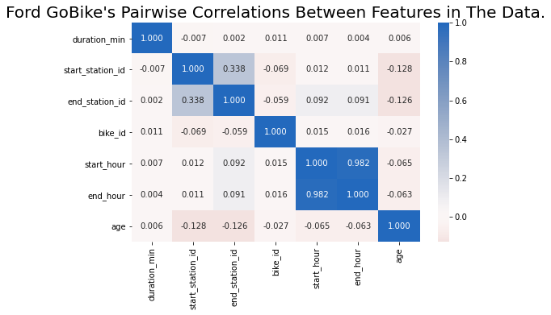

```python
# correlation plot
plt.figure(figsize = [8, 5])
sb.heatmap(df[numeric_vars].corr(), annot = True, fmt = '.3f',
           cmap = 'vlag_r', center = 0)

# Labeling the axes
plt.title(label = "Ford GoBike's Pairwise Correlations Between Features in The Data.", fontsize=20, loc='center');
plt.show()
```

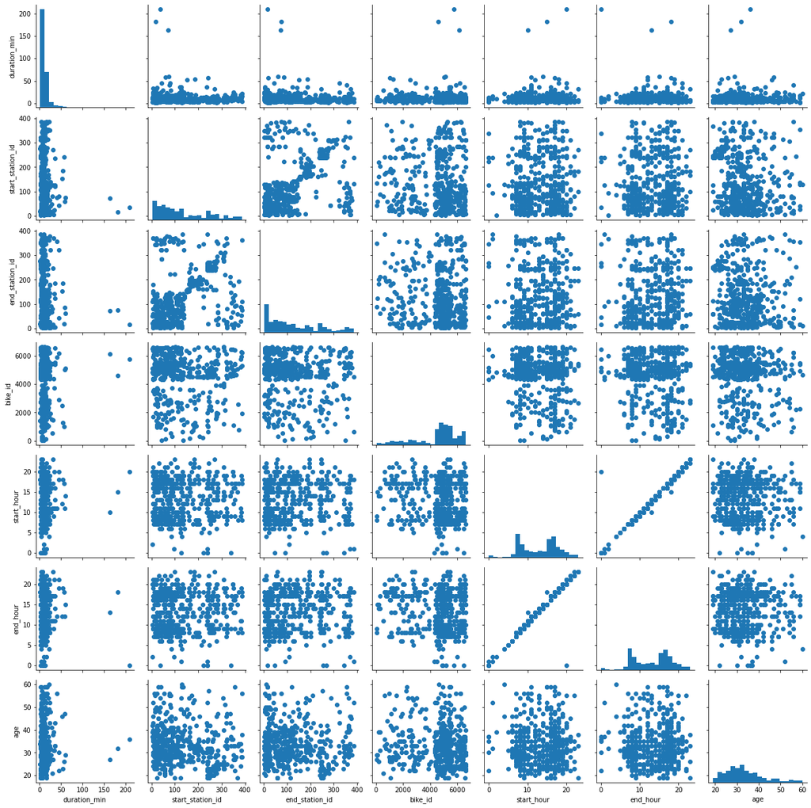

```python
samples = np.random.choice(df.shape[0], 500, replace = False)
df_samp = df.reindex(samples)

g = sb.PairGrid(data = df_samp, vars = numeric_vars)
g = g.map_diag(plt.hist, bins = 20);
g.map_offdiag(plt.scatter)
```

**Obviously, there's a strong correlation between the start and end hours, and a weak correlation between start and end stations.**

[output not shown]

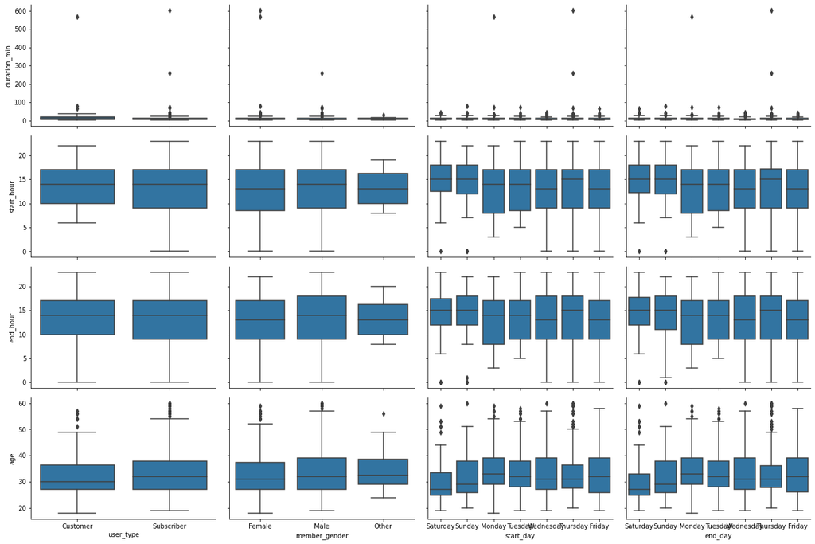

```python
# plot matrix of numeric features against categorical features.
# can use a larger sample since there are fewer plots and they're simpler in nature.

samples = np.random.choice(df.shape[0], 1000, replace = False)
df_samp = df.reindex(samples)

def boxgrid(x, y, **kwargs):
    base_color = sb.color_palette()[0]
    sb.boxplot(x, y, color = base_color)

plt.figure(figsize = [10, 10])
g = sb.PairGrid(data = df_samp, y_vars = ['duration_min', 'start_hour', 'end_hour', 'age'],
                x_vars = categoric_vars, size = 3, aspect = 1.5)
g.map(boxgrid)
plt.show();
```

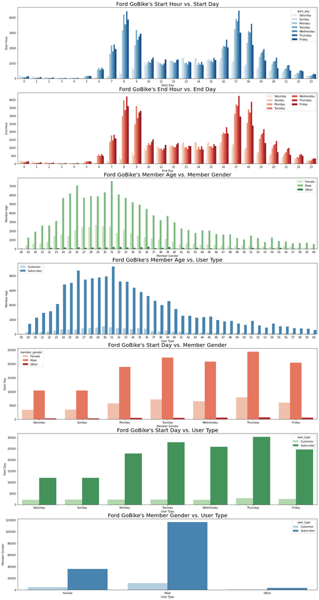

```python
# since there's only 7 subplots to create, using the full data should be fine.
plt.figure(figsize = [20, 40])

# subplot 1:
plt.subplot(7, 1, 1)
sb.countplot(data = df, x = 'start_hour', hue = 'start_day', palette = 'Blues')
# Labeling the axes
plt.ylabel('Start Hour')
plt.xlabel('Start Day')
plt.title(label = "Ford GoBike's Start Hour vs. Start Day", fontsize=20, loc='center');

# subplot 2:
ax = plt.subplot(7, 1, 2)
sb.countplot(data = df, x = 'end_hour', hue = 'end_day', palette = 'Reds')
ax.legend(ncol = 2) # re-arrange legend to reduce overlapping
# Labeling the axes
plt.ylabel('End Hour')
plt.xlabel('End Day')
plt.title(label = "Ford GoBike's End Hour vs. End Day", fontsize=20, loc='center');

# subplot 3:
ax = plt.subplot(7, 1, 3)
sb.countplot(data = df, x = 'age', hue = 'member_gender', palette = 'Greens')
ax.legend(loc = 1) # re-arrange legend to remove overlapping
# Labeling the axes
plt.ylabel('Member Age')
plt.xlabel('Member Gender')
plt.title(label = "Ford GoBike's Member Age vs. Member Gender", fontsize=20, loc='center');

# subplot 4:
ax = plt.subplot(7, 1, 4)
sb.countplot(data = df, x = 'age', hue = 'user_type', palette = 'Blues')
ax.legend(loc = 'upper left') # re-arrange legend to remove overlapping
# Labeling the axes
plt.ylabel('Member Age')
plt.xlabel('User Type')
plt.title(label = "Ford GoBike's Member Age vs. User Type", fontsize=20, loc='center');

# subplot 5:
ax = plt.subplot(7, 1, 5);
sb.countplot(data = df, x = 'start_day', hue = 'member_gender', palette = 'Reds');
# Labeling the axes
plt.ylabel('Start Day')
plt.xlabel('Member Gender')
plt.title(label = "Ford GoBike's Start Day vs. Member Gender", fontsize=20, loc='center');

# subplot 6:
ax = plt.subplot(7, 1, 6);
sb.countplot(data = df, x = 'start_day', hue = 'user_type', palette = 'Greens');
# Labeling the axes
plt.ylabel('Start Day')
plt.xlabel('User Type')
plt.title(label = "Ford GoBike's Start Day vs. User Type", fontsize=20, loc='center');

# subplot 7:
ax = plt.subplot(7, 1, 7);
sb.countplot(data = df, x = 'member_gender', hue = 'user_type', palette = 'Blues');
# Labeling the axes
plt.ylabel('Member Gender')
plt.xlabel('User Type')
plt.title(label = "Ford GoBike's Member Gender vs. User Type", fontsize=20, loc='center');

plt.show()
```

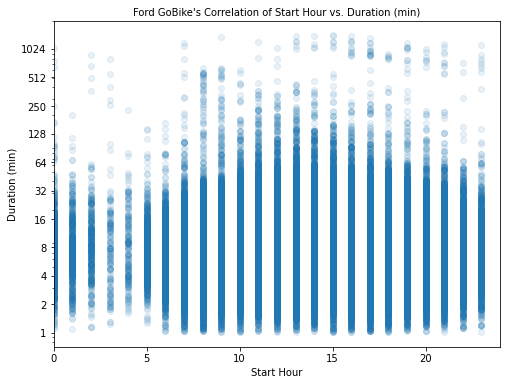

```python
# scatter plot of duration_min vs. start_day, with log transform on duration axis
samples = np.random.choice(df.shape[0], 10000, replace = False)
df_samp = df.reindex(samples)

plt.figure(figsize = [8, 6])
plt.scatter(data = df, x = 'start_hour', y = 'duration_min', alpha = 1/10)
#sb.violinplot(data = df_samp, x = 'start_hour', y= df['duration_min']/60, color=base_color, inner='quartile');
plt.xlim([0, 24])
#plt.ylim([0, 1])
plt.yscale('log');
plt.yticks([1, 2, 4, 8, 16, 32, 64, 128, 250, 512, 1024], [1, 2, 4, 8, 16, 32, 64, 128, 250, 512, 1024]);
plt.xlabel('Start Hour')
plt.ylabel('Duration (min)')
plt.title(label = "Ford GoBike's Correlation of Start Hour vs. Duration (min)", fontsize=10, loc='center');
plt.show()
```

```python
# compute the logarithm of price to make multivariate plotting easier
def log_trans(x, inverse = False):
    """ quick function for computing log and power operations """
    if not inverse:
        return np.log10(x)
    else:
        return np.power(10, x)

df['duration_min_log'] = df['duration_min'].apply(log_trans)
```

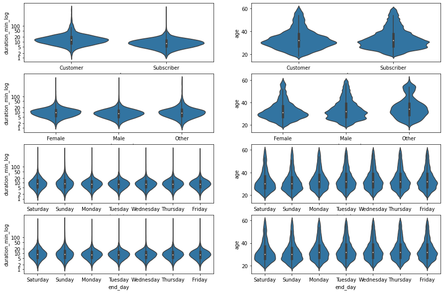

```python
# plot the categorical variables against duration_min and member_age again, this time
# with full data and variable transforms
fig, ax = plt.subplots(ncols = 2, nrows = 4 , figsize = [15,10])
for i in range(len(categoric_vars)):
    var = categoric_vars[i]
    sb.violinplot(data = df, x = var, y = 'duration_min_log', ax = ax[i,0], color = base_color);
    ax[i,0].set_yticks(log_trans(np.array([1, 2, 5, 10, 20, 50, 100])));
    ax[i,0].set_yticklabels([1, 2, 5, 10, 20, 50, 100]);
    sb.violinplot(data = df, x = var, y = 'age', ax = ax[i,1], color = base_color);
```

**The use a violin plot and variable transformations reveals much similarity between the categorical variables in relation to age and duration except for gender vs. age. Also, We can see a perfect correspond between start day and end day in relation to ages and duration (min) in a log scale.**

### Did you observe any interesting relationships between the other features (not the main feature(s) of interest)?

> I noticed a great similarity between the categorical variables in relation to age and duration except for gender vs. age. There were a perfect correspond between start day and end day in relation to ages and duration (min) in a log scale.

## Multivariate Exploration

> Create plots of three or more variables to investigate your data even further. Make sure that your investigations are justified, and follow from your work in the previous sections.

```python
def hist2dgrid(x, y, **kwargs):
    """ Quick hack for creating heat maps with seaborn's PairGrid. """
    palette = kwargs.pop('color');
    bins_x = np.arange(df['age'].min(), df['age'].max()+1, 1);
    bins_y = np.arange(0, 2, 0.1);
    plt.hist2d(x, y, bins = [bins_x, bins_y], cmap = palette, cmin = 0.5);
    plt.yticks(log_trans(np.array([1, 2, 4, 8, 16, 32, 64])), [1, 2, 4, 8, 16, 32, 64]);
```

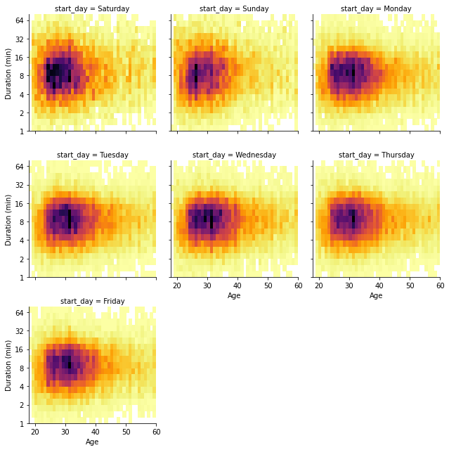

```python
# create faceted heat maps on levels of the age variable
g = sb.FacetGrid(data = df, col = 'start_day', col_wrap = 3, size = 3)
g.map(hist2dgrid, 'age', 'duration_min_log', color = 'inferno_r')
g.set_xlabels('Age')
g.set_ylabels('Duration (min)')
plt.show()
```

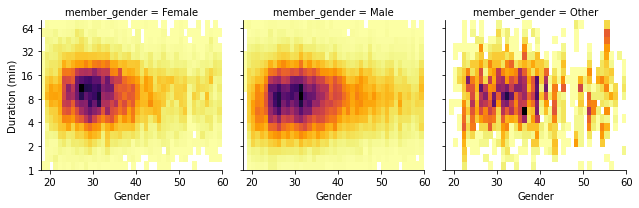

```python
# create faceted heat maps on levels of the age variable
g = sb.FacetGrid(data = df, col = 'member_gender', col_wrap = 3, size = 3)
g.map(hist2dgrid, 'age', 'duration_min_log', color = 'inferno_r')
g.set_xlabels('Gender')
g.set_ylabels('Duration (min)')

plt.show()
```

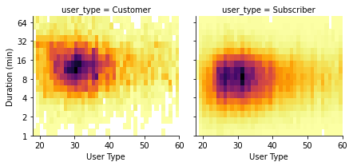

```python
# create faceted heat maps on levels of the age variable
g = sb.FacetGrid(data = df, col = 'user_type', col_wrap = 3, size = 3)
g.map(hist2dgrid, 'age', 'duration_min_log', color = 'inferno_r')
g.set_xlabels('User Type')
g.set_ylabels('Duration (min)')

plt.show()
```

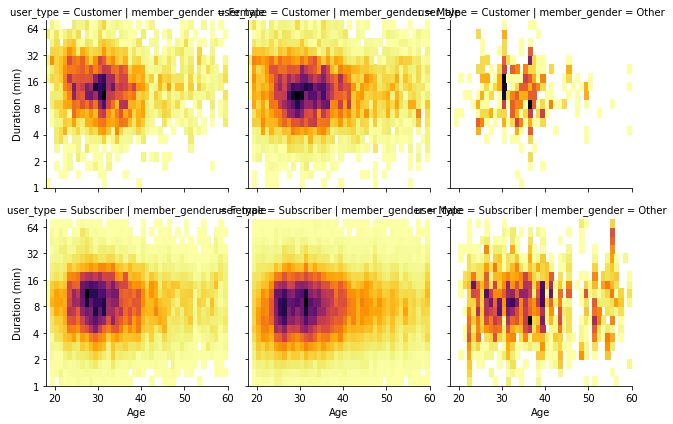

```python
# create faceted heat maps on levels of the age variable
g = sb.FacetGrid(data = df, col = 'member_gender', row = 'user_type', size = 3)
g.map(hist2dgrid, 'age', 'duration_min_log', color = 'inferno_r')
g.set_xlabels('Age')
g.set_ylabels('Duration (min)')

plt.show()
```

**The Facet Grid indicated that most variables are concentrated between 4-16 in relation to duration (min) and between 25-35 in relation to age.**

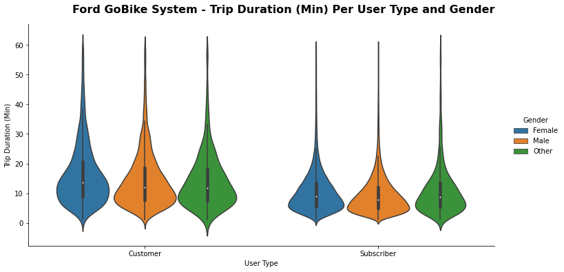

```python
# Violinplot - duration (min) per user type and gender

graph = sb.catplot(data=zdur, x='user_type', y="duration_min", hue="member_gender", kind="violin", height=5, aspect=2);

graph.set_axis_labels("User Type", "Trip Duration (Min)")
graph._legend.set_title('Gender')
graph.fig.suptitle('Ford GoBike System - Trip Duration (Min) Per User Type and Gender', y=1.05, fontsize=16, fontweight='bold');
```

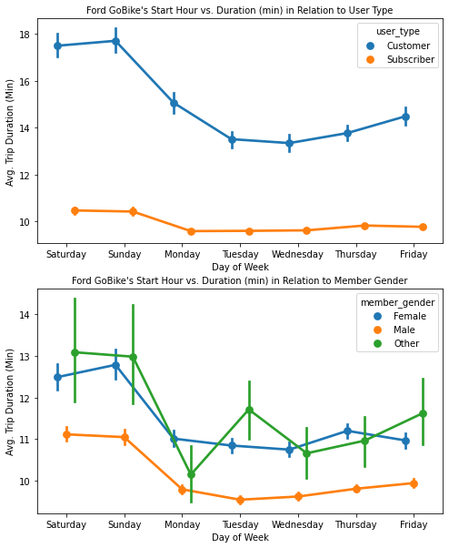

```python
fig = plt.figure(figsize = [8,10])

# subplot 1:
plt.subplot(2, 1, 1)
sb.pointplot(data=zdur, x='start_day', y='duration_min', hue='user_type', dodge=0.3);
plt.xlabel('Day of Week');
plt.ylabel('Avg. Trip Duration (Min)');
plt.title(label = "Ford GoBike's Start Hour vs. Duration (min) in Relation to User Type", fontsize=10, loc='center');

# subplot 2:
plt.subplot(2, 1, 2)
sb.pointplot(data=zdur, x='start_day', y='duration_min', hue='member_gender', dodge=0.3);
plt.xlabel('Day of Week');
plt.ylabel('Avg. Trip Duration (Min)');
plt.title(label = "Ford GoBike's Start Hour vs. Duration (min) in Relation to Member Gender", fontsize=10, loc='center');

plt.show();
```

**For both user type and member gender, weekend has the highest average of trip duration in minutes.**

### Were there any interesting or surprising interactions between features?

> Maybe the most active days are business days, but the weekend has the longest trip duration. That's interesting because indeed people on the weekend tends to lag a little, opposite to weekdays when people are more active and hurry.

```python
df.to_csv('fordgobike-trip-data.csv', index=False)
```

> At the end of your report, make sure that you export the notebook as an html file from the `File > Download as... > HTML` menu. Make sure you keep track of where the exported file goes, so you can put it in the same folder as this notebook for project submission. Also, make sure you remove all of the quote-formatted guide notes like this one before you finish your report!